# Evaluation, Efficiency, and Adapter Packaging

**Hugging Face Models and Fine-Tuning · Lecture 4 · self-paced tutorial**  
**Estimated study time:** 60–90 minutes, excluding model downloads and optional large-model extensions  
**Typical code runtime:** 25–35 minutes

## Learning outcomes

- Compare adaptation strategies.
- Explain LoRA rank and QLoRA memory savings.
- Evaluate and package an adapter reproducibly.

| Learning stage | What you will do |
| --- | --- |
| Orient | Read the driving question and prerequisite recap. |
| Build intuition | Work through the visual model and hand calculation. |
| Implement | Run the code in order and investigate the first failed check. |
| Consolidate | Complete the practice checkpoint and summarize the evidence. |

## Driving question

> **How can we attribute an improvement to an adapter and package it so another person can reproduce the comparison?**

Keep this question in mind as you work. Each calculation, figure, and code cell gives you one more piece of the answer.

### Before you begin

Recall base versus adapted models, fixed decoding, held-out prompts, adapter configuration, and the difference between validation loss and open-ended behavior.

Evaluation begins before training by freezing prompts, reference expectations, decoding settings, and rubric definitions. A useful comparison includes the unadapted base, a prompted baseline, LoRA, and QLoRA when available. It evaluates target behavior and retention, because an adapter can improve formatting while damaging unrelated capabilities. Per-example records make aggregate scores auditable.

## How this lesson builds, step by step

We begin with a result we can check by hand, make it reusable, and then test something that could still be wrong even when the code runs:

1. **Compare adapter parameter counts.** Quantify efficiency without turning it into a quality claim. The checkpoint is useful only when the observed output supports this purpose.
2. **Define method contracts.** State what is frozen, quantized, and mergeable for each method. The checkpoint is useful only when the observed output supports this purpose.
3. **Create auditable evaluation records.** Make every score traceable to prompts, artifacts, and outputs. The checkpoint is useful only when the observed output supports this purpose.
4. **Describe save, reload, and merge verification.** Make adapter deployment behavior testable rather than a packaging slogan. The checkpoint is useful only when the observed output supports this purpose.

If an early result differs from your prediction, stop there. Check its structure, its numerical values, and its behavior on a small example. A larger model only makes an early mistake harder to find.

## Reproducible setup

Evaluation is paired: every model variant receives the same held-out prompts and greedy decoding budget. The notebook uses the real adapter produced by Lecture 03 and refuses to invent outputs when that artifact is absent.

```python
from pathlib import Path
import json, random, sys

COURSE_ROOT = next(
    candidate for candidate in (Path.cwd().resolve(), *Path.cwd().resolve().parents)
    if (candidate / "course_helpers.py").is_file()
)
if str(COURSE_ROOT) not in sys.path:
    sys.path.insert(0, str(COURSE_ROOT))

SEED = 2026
random.seed(SEED)
print("Course folder:", COURSE_ROOT)
```

### Fine-tuning methods trade memory for flexibility

Full tuning, LoRA, and QLoRA store and update different sets of tensors.

**Check your understanding:** Which comparison is about engineering cost rather than an automatic ranking of output quality?

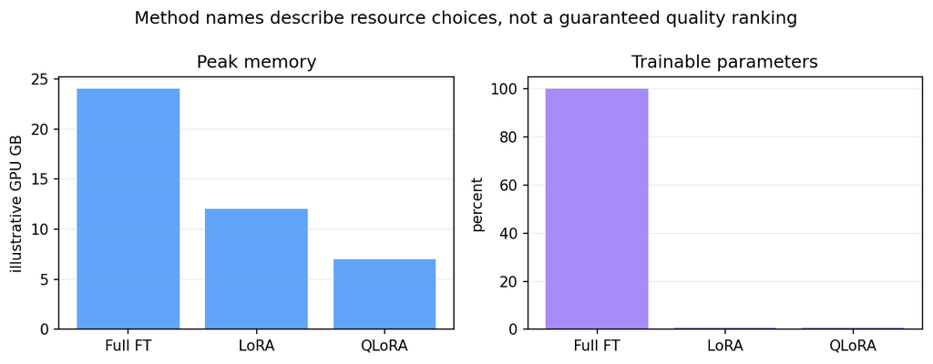

## Learn and test: Compare adapter parameter counts

LoRA replaces a weight update with $\Delta W=BA$ of rank $r$. QLoRA quantizes frozen base weights while retaining higher-precision adapter training. Evaluation must compare the same prompts and decoding settings against the unadapted base.

## Choosing an adaptation method

Full fine-tuning updates every parameter and optimizer state, offering maximum flexibility at high memory and storage cost. LoRA trains small low-rank matrices alongside frozen full-precision weights. QLoRA stores the frozen base in low precision while training adapters at higher precision, reducing memory further. These are engineering choices, not a guaranteed quality ordering.

### Work the smallest useful example

A paired record stores prompt ID, model and adapter revisions, exact generation settings, outputs from each variant, latency, memory, and rubric fields. Holding prompts and decoding fixed removes two major confounders. Adapter storage may be small, but deployment also needs the compatible base, tokenizer, chat template, and software environment. Merging adds the adapter delta to base weights; it does not erase provenance or licensing obligations.

Keep this result visible. The code should reproduce the same relationship; if it does not, locate the first value that differs before changing the model.

### Try it: Compare adapter parameter counts

**What this cell shows**

Quantify efficiency without turning it into a quality claim.

**What goes in and comes out**

- Dense and adapter counts are integers derived from input width, output width, and rank.

**Follow the calculation**

1. Compute `r(in+out)` and divide by `in·out` for several ranks.

**Before you run the cell**

How does doubling rank change adapter count? Write down the expected value, shape, or ordering before running the cell.

```python
def lora_parameters(in_features, out_features, rank):
    return rank * (in_features + out_features)
dense = 4096 * 4096
for rank in (4, 8, 16, 64):
    adapter = lora_parameters(4096, 4096, rank)
    print(rank, f"{adapter:,}", f"{100*adapter/dense:.3f}% of dense")
```

**What you should see**

Trainable values grow linearly with rank, whereas the dense matrix size is fixed.

**If your result looks different**

Parameter percentage omits activations, quantization buffers, and runtime kernels.

Before moving on, compare the output with your prediction. If they differ, use the data description and tensor shapes above to find the first unexpected step.

## Learn and test: Define method contracts

For a dense `d × k` matrix, a LoRA update with rank `r` contains `r(d+k)` trainable values instead of `dk`. Rank should be treated as a capacity hyperparameter. Targeting more modules or using a larger rank increases expressiveness and adapter size. Merging adds the learned update into a compatible base model for simpler inference, but preserving the separate adapter is often better for provenance and reuse.

### Base and instruction models learned different response conventions

A base model continues text, while an instruction model has been trained to respond to role-structured messages.

**Check your understanding:** What must remain fixed to compare their behavior fairly?

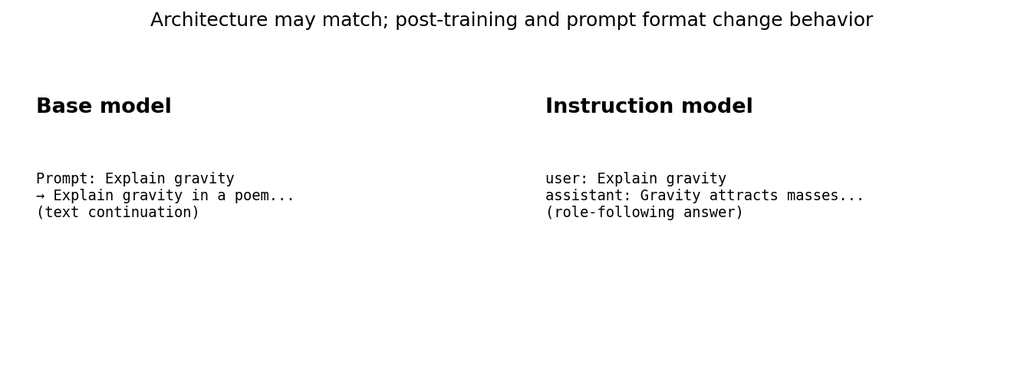

### Try it: Define method contracts

**What this cell shows**

State what is frozen, quantized, and mergeable for each method.

**What goes in and comes out**

- A method table maps names to Boolean or descriptive properties.

**Follow the calculation**

1. Separate trainability from storage precision and deployment form
2. these dimensions are often conflated.

**Before you run the cell**

Which method keeps a quantized frozen base during training? Write down the expected value, shape, or ordering before running the cell.

```python
methods = {
    "full": {"base_trainable": True, "quantized": False, "mergeable": "already merged"},
    "LoRA": {"base_trainable": False, "quantized": False, "mergeable": True},
    "QLoRA": {"base_trainable": False, "quantized": True, "mergeable": "after dequantized load"},
}
print(json.dumps(methods, indent=2))
```

**What you should see**

QLoRA combines quantized base storage with trainable adapters.

**If your result looks different**

Do not label one method 'best' without paired task and retention evidence.

Before moving on, compare the output with your prediction. If they differ, use the data description and tensor shapes above to find the first unexpected step.

## Learn and test: Create auditable evaluation records

A fair comparison holds the dataset, number of optimizer updates or token budget, prompt set, and decoding configuration fixed. Report trainable parameters, peak memory, wall time, adapter size, validation loss, task rubric scores, and retention behavior. Quantized training may introduce version- and hardware-specific behavior, so record the exact stack.

### Packaging contract

An adapter alone is incomplete. Package its config and weights with base model ID/revision, tokenizer revision, chat template, training configuration, data-manifest checksum, software versions, evaluation report, intended use, and known limitations.

### Choose checkpoints with held-out behavior

Training loss can keep falling after validation loss stops improving.

**Check your understanding:** Which checkpoint would you keep, and what would be wrong with automatically taking the final step?

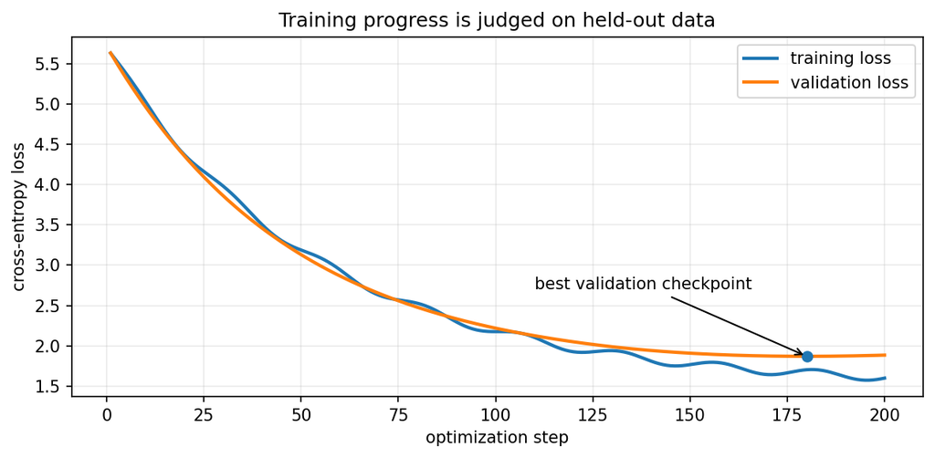

### Try it: Create auditable evaluation records

**What this cell shows**

Make every score traceable to prompts, artifacts, and outputs.

**What goes in and comes out**

- Each record is JSON-compatible and keyed by stable prompt ID.

**Follow the calculation**

1. Store revisions and generation settings beside base/adapted outputs and unfilled rubric fields before judging.

**Before you run the cell**

Which fields must remain identical across variants? Write down the expected value, shape, or ordering before running the cell.

```python
from course_helpers import read_jsonl

eval_rows = read_jsonl(COURSE_ROOT / "data" / "evaluation" / "sft_evaluation.jsonl")
fixed_rows = eval_rows[:8]
evaluation_contract = {
    "prompt_ids": [row["id"] for row in fixed_rows],
    "decoding": {"do_sample": False, "max_new_tokens": 80},
    "checks": ["nonempty", "requested format", "unsupported claim", "retention"],
    "selection_rule": "first eight rows before viewing model outputs",
}
print(json.dumps(evaluation_contract, indent=2))
print("example prompt:", fixed_rows[0]["messages"][-2]["content"][:240])
```

**What you should see**

Prompt, decoding, token budget, and rubric remain fixed; model/adapter identity changes.

**If your result looks different**

Filling rubric labels while tuning on the same examples leaks evaluation feedback.

Before moving on, compare the output with your prediction. If they differ, use the data description and tensor shapes above to find the first unexpected step.

### Try it: Describe save, reload, and merge verification

**What this cell shows**

Make adapter deployment behavior testable rather than a packaging slogan.

**What goes in and comes out**

- The guarded path uses a compatible base model, adapter directory, fixed token batch, and two sets of logits.

**Follow the calculation**

1. Load the base revision, attach the adapter, compute reference logits, call merge-and-unload, recompute, and compare within tolerance before saving.

**Before you run the cell**

Should merging materially change logits relative to the active unmerged adapter? Write down the expected value, shape, or ordering before running the cell.

```python
import torch
from peft import PeftModel
from transformers import AutoModelForCausalLM, AutoTokenizer
from course_helpers import (
    CLASSROOM_MODEL, CLASSROOM_REVISION,
    fixed_generate, directory_size,
)

adapter_dir = COURSE_ROOT / "adapters" / "classroom_smol_lora"
if not adapter_dir.exists():
    raise FileNotFoundError(
        "The PEFT adapter is missing. Run Lecture 03's two-step training cell first."
    )

tokenizer = AutoTokenizer.from_pretrained(adapter_dir)
dtype = torch.bfloat16 if torch.cuda.is_available() else torch.float32
base = AutoModelForCausalLM.from_pretrained(
    CLASSROOM_MODEL, revision=CLASSROOM_REVISION, dtype=dtype,
)
adapted = PeftModel.from_pretrained(base, adapter_dir, is_trainable=False).eval()
print("adapter size (MiB):", round(directory_size(adapter_dir) / 2**20, 2))
```

The directory must contain a PEFT configuration and adapter weights, and its base model must match the pinned revision. Loading succeeds before we attempt a merge; this separates an artifact-lineage failure from a numerical-equivalence failure.

## Learn and test: collect paired outputs before scoring them

We preserve each held-out row's final user prompt and its human-authored assistant answer. The reference is evidence for review, not a string that the generated answer must copy. Base and adapter calls use identical greedy settings.

### Try it: generate base and adapter records

**Before running:** expect the run to be slow on CPU because each prompt is evaluated twice. Do not change the prompt subset after seeing weak examples.

**Inputs and outputs:** The named Python objects enter this step; the printed values, token counts, tensor shapes, or saved files are the observations to check.

```python
records = []
for row in fixed_rows:
    prompt_messages = row["messages"][:-1]
    with adapted.disable_adapter():
        base_output = fixed_generate(
            adapted, tokenizer, prompt_messages, max_new_tokens=80
        )
    adapter_output = fixed_generate(
        adapted, tokenizer, prompt_messages, max_new_tokens=80
    )
    records.append({
        "prompt_id": row["id"],
        "prompt": prompt_messages,
        "reference": row["messages"][-1]["content"],
        "base_output": base_output,
        "adapter_output": adapter_output,
    })
print(json.dumps(records[0], indent=2, ensure_ascii=False)[:1800])
```

Each record now contains traceable text rather than an ellipsis or a manually typed claim. Inspect whether the output is nonempty and follows the requested form, then review factual support against the human response. With only two training steps, “no clear improvement” is a legitimate result.

### Try it: create a small auditable scorecard

This mechanical check measures only response presence and rough length. It must be accompanied by human review; a long answer can still be wrong, and a short answer may be exactly what the prompt requested.

**Inputs and outputs:** The named Python objects enter this step; the printed values, token counts, tensor shapes, or saved files are the observations to check.

```python
for record in records:
    record["base_nonempty"] = bool(record["base_output"].strip())
    record["adapter_nonempty"] = bool(record["adapter_output"].strip())
    record["base_words"] = len(record["base_output"].split())
    record["adapter_words"] = len(record["adapter_output"].split())

summary = {
    "examples": len(records),
    "base_nonempty": sum(row["base_nonempty"] for row in records),
    "adapter_nonempty": sum(row["adapter_nonempty"] for row in records),
}
print(summary)
```

The scorecard verifies that the pipeline produced comparable records; it does not establish semantic quality. Add blinded human labels for target behavior, correctness, and retention before making a deployment claim. Always report the denominator and show at least one failure from each variant.

## Learn and test: Describe save, reload, and merge verification

**Common misconception:** merging an adapter does not remove its data or licensing provenance. The resulting weights still arise from both base and adaptation sources.

### An adapter depends on a complete lineage

The base revision, tokenizer, training data, configuration, software, and evaluation all remain part of the artifact.

**Check your understanding:** Which missing dependency would make the small adapter file impossible to reproduce or review?

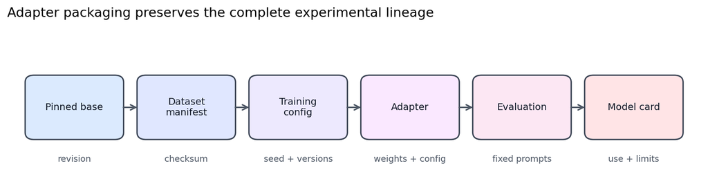

### Try it: merge and verify logits

Merging folds the low-rank update into ordinary model weights. We compare one forward pass before and after merging. Small floating-point differences are expected; a changed tensor shape or large error indicates a packaging problem.

**Inputs and outputs:** The named Python objects enter this step; the printed values, token counts, tensor shapes, or saved files are the observations to check.

```python
check_messages = fixed_rows[0]["messages"][:-1]
batch = tokenizer.apply_chat_template(
    check_messages, tokenize=True, add_generation_prompt=True,
    return_tensors="pt", return_dict=True,
)
device = next(adapted.parameters()).device
batch = {key: value.to(device) for key, value in batch.items()}
adapted.eval()
with torch.inference_mode():
    before = adapted(**batch).logits.float().cpu()
merged = adapted.merge_and_unload().eval()
merged_device = next(merged.parameters()).device
merged_batch = {key: value.to(merged_device) for key, value in batch.items()}
with torch.inference_mode():
    after = merged(**merged_batch).logits.float().cpu()
difference = (before - after).abs()
print("shape:", tuple(before.shape))
print("maximum absolute difference:", difference.max().item())
print("mean absolute difference:", difference.mean().item())
```

The shapes must match exactly and the maximum difference should be small relative to ordinary logits. Save the merged model only if deployment requires a single weight set; keeping the adapter separate is smaller and preserves the distinction between shared base weights and task-specific changes.

**What you should see**

No. Correct merging changes packaging, not the effective forward computation, apart from small numerical differences.

**If your result looks different**

Merging into the wrong base revision can load incorrectly or silently invalidate equivalence; verify identity first.

Before moving on, compare the output with your prediction. If they differ, use the data description and tensor shapes above to find the first unexpected step.

### Packaging checklist

Save adapter weights/config, base model ID and revision, tokenizer/chat template, training config, data manifest hash, dependency versions, evaluation report, model card, and known limitations.

## A realistic failure—and what it teaches us

Comparing different token budgets, selecting examples after seeing results, or reporting only showcase outputs invalidates attribution. A merged model should be checked against the unmerged base-plus-adapter using identical inputs and tolerance-aware logits. The model card must state intended use, data, limitations, and evaluation failures rather than functioning as promotional text.

**Debugging habit:** find the first expectation that failed—data identity, shape, normalization, causality, optimization, retrieval, grounding, or authorization. Then write the smallest check that separates that problem from the nearby possibilities.

## Practice checkpoint

For a 1.5B-parameter model, estimate weight-only memory in BF16 and INT4, then list two major allocations the estimate omits.

Before editing code, write a prediction and name the invariant that should remain true. Record the observed result in this notebook, compare it with your prediction, and write one sentence explaining any discrepancy.

## Instructor check-in

After running the practice checkpoint, send a short email from your Clemson account. Include your full name, Clemson email, observed evidence, and interpretation.

**Evidence to include:** Report which output won your paired comparison and one concrete reason, then include the maximum logit difference from the merge check.

The final line is not only for problems. You may send a question **or** describe something that worked well or changed your understanding.

📧 Send the checkpoint email

If the button does not open your Clemson mail client, email fanchem@clemson.edu with the subject **Watt AI lesson check-in — Lesson 04 - Evaluation and adapter packaging** and use the same fields above.

## Check your work

Expand the reference solution only after attempting the exercise.

```python
params = 1.5e9
print("BF16 GiB", params * 2 / 2**30, "INT4 GiB", params * 0.5 / 2**30)
print("Omitted: activations, gradients/adapters, optimizer states, temporary kernels, KV cache")
```

## Final concept map

Frozen evaluation contract → paired generations → target and retention metrics → qualitative failure review → resource tradeoff → adapter save/reload → optional merge equivalence → artifact lineage → model card and reproduction command.

Return to the driving question: **How can we attribute an improvement to an adapter and package it so another person can reproduce the comparison?** Explain the answer without using library names. Then identify which new limitation motivates the next lecture.

## Homework

Create an adapter model card and evaluation report comparing base, LoRA, and QLoRA under identical prompts, seeds, and decoding.

The full assignment and rubric are in this course's `homework/` folder. Attempt the work before opening the collapsed check-your-work cell above.

## Glossary

| Term | Meaning in this lesson |
| --- | --- |
| **paired evaluation** | Comparing variants on identical examples. |
| **retention** | Preservation of capabilities outside the adaptation target. |
| **adapter merge** | Adding learned deltas into compatible base weights. |
| **artifact lineage** | Trace from base/data/config to adapter and evaluation. |
| **model card** | Documentation of use, evidence, provenance, and limitations. |
| **format compliance** | Whether output follows the required structural contract. |

A useful definition lets you predict behavior. Test yourself by giving one example and one non-example for every term rather than memorizing the wording.

## Sources and further study

The explanations, code, numeric examples, and figures in this notebook are course-original. These primary or official sources check terminology and provide a deeper path:

- [PEFT LoRA Guide](https://huggingface.co/docs/peft/main/conceptual_guides/lora) — Official adapter concepts and configuration meanings.
- [QLoRA](https://arxiv.org/abs/2305.14314) — Primary source for NF4, double quantization, and paged optimizers.
- [Clemson CITI fine-tuning workshop](https://clemsonciti.github.io/rcde_workshops/llms_finetune/00-index.html) and [alternatives to fine-tuning](https://clemsonciti.github.io/rcde_workshops/llms_finetune/01-alternatives.html) — optional structural comparison and further reading; no workshop prose or images are copied.
- [SmolLM2-135M-Instruct model card](https://huggingface.co/HuggingFaceTB/SmolLM2-135M-Instruct) — pinned classroom artifact and license.
- [Bitsandbytes quantization](https://huggingface.co/docs/transformers/quantization/bitsandbytes) — official four-bit loading behavior.

Source role: conceptual or implementation verification. Accessed 2026-08-18. External images are not hotlinked; redistributed assets require the course license manifest.